# Integrative analysis workshop with TCGAbiolinks and ELMER

Tiago Chedraoui Silva, Simon Coetzee, Ben Berman, Houtan Noushmehr

2017-07-13

# Introduction

Another Bioconductor package we will also be introduce is called [ELMER](http://bioconductor.org/packages/ELMER/) (L. Yao et al. 2015,Chedraoui Silva et al. (2017)) which allows one to identify DNA methylation changes in distal regulatory regions and correlate these signatures with expression of nearby genes to identify transcriptional targets associated with cancer. For these distal probes correlated with a gene, a transcription factor motif analysis is performed followed by expression analysis of transcription factors to infer upstream regulators.

We expect that participants of this workshop will understand the integrative analysis performed by using [TCGAbiolinks](http://bioconductor.org/packages/TCGAbiolinks/) + [ELMER](http://bioconductor.org/packages/ELMER/), as well as be able to execute it from the data acquisition process to the final interpretation of the results. The workshop assumes users with an intermediate level of familiarity with R, and basic understanding of tumor biology.

The figure below hihglights the workflow part which will be covered in this section.

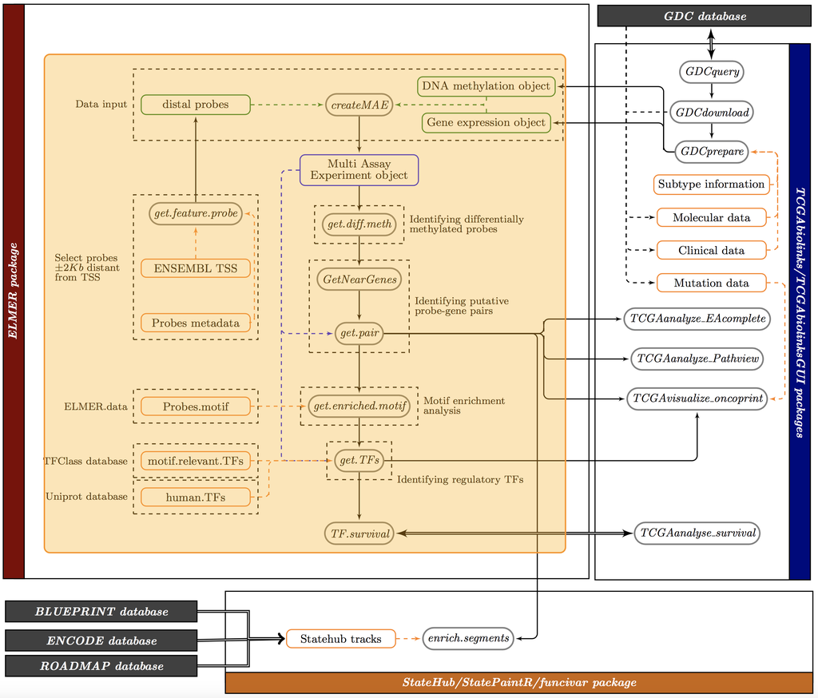

## Loading required libraries

```r
library(ELMER)
library(DT)
library(dplyr)
```

# ELMER data input

A Multi Assay Experiment object from the *MultiAssayExperiment* package is the input for multiple main functions of *ELMER*. To create it you can use the `createMAE` function.

But instead of using the data downloaded previously we will use one with more samples provided in this package.

```r
library(MultiAssayExperiment)
lusc.exp
```

```
## class: RangedSummarizedExperiment
## dim: 3742 234
## metadata(0):
## assays(1): ''
## rownames(3742): ENSG00000188984 ENSG00000204518 ...
##   ENSG00000162378 ENSG00000036549
## rowData names(2): external_gene_name ensembl_gene_id
## colnames(234): TCGA-22-5472-01A-01R-1635-07
##   TCGA-22-5489-01A-01R-1635-07 ... TCGA-56-7730-01A-11R-2125-07
##   TCGA-56-7731-01A-11R-2125-07
## colData names(0):
```

```r
lusc.met
```

```
## class: RangedSummarizedExperiment
## dim: 1702 268
## metadata(0):
## assays(1): ''
## rownames(1702): cg00045114 cg00050294 ... cg13985485 cg08542090
## rowData names(36): addressA addressB ... MASK.extBase MASK.general
## colnames(268): TCGA-43-3394-11A-01D-1551-05
##   TCGA-43-3920-11B-01D-1551-05 ... TCGA-98-8022-01A-11D-2245-05
##   TCGA-98-8023-01A-11D-2245-05
## colData names(1): samples
```

Also we will need to filter the probes in the MAE to select only distal probes.

```r
distal.probes <- get.feature.probe(genome = "hg38", met.platform = "450K")
```

The `createMAE` function will receive both DNA methylation and gene expression objects. Also `filter.probes` argument will select only probes in the regions of the distal.probes object.

```r
library(MultiAssayExperiment)
mae <- createMAE(exp = lusc.exp,
                 met = lusc.met,
                 save = TRUE,
                 linearize.exp = TRUE,
                 filter.probes = distal.probes,
                 save.filename = "mae_bioc2017.rda",
                 met.platform = "450K",
                 genome = "hg19",
                 TCGA = TRUE)
mae
```

```
## A MultiAssayExperiment object of 2 listed
##  experiments with user-defined names and respective classes.
##  Containing an ExperimentList class object of length 2:
##  [1] DNA methylation: RangedSummarizedExperiment with 1584 rows and 234 columns
##  [2] Gene expression: RangedSummarizedExperiment with 3742 rows and 234 columns
## Features:
##  experiments() - obtain the ExperimentList instance
##  colData() - the primary/phenotype DataFrame
##  sampleMap() - the sample availability DataFrame
##  `$`, `[`, `[[` - extract colData columns, subset, or experiment
##  *Format() - convert ExperimentList into a long or wide DataFrame
##  assays() - convert ExperimentList to a SimpleList of matrices
```

```r
colData(mae)[1:5,] %>%  as.data.frame %>% datatable(options = list(scrollX = TRUE))
```

|  | patient | sample | shortLetterCode | definition | classification_of_tumor | last_known_disease_status | updated_datetime.x | primary_diagnosis | tumor_stage | age_at_diagnosis | vital_status | morphology | days_to_death | days_to_last_known_disease_status | created_datetime.x | state.x | days_to_recurrence | diagnosis_id | tumor_grade | treatments | tissue_or_organ_of_origin | days_to_birth | progression_or_recurrence | prior_malignancy | site_of_resection_or_biopsy | days_to_last_follow_up | cigarettes_per_day | weight | updated_datetime.y | … |
| --- | --- | --- | --- | --- | --- | --- | --- | --- | --- | --- | --- | --- | --- | --- | --- | --- | --- | --- | --- | --- | --- | --- | --- | --- | --- | --- | --- | --- | --- | --- |
| TCGA-43-3394-11A | TCGA-43-3394 | TCGA-43-3394-11A | NT | Solid Tissue Normal | not reported | not reported | 2017-03-04T16:44:35.784223-06:00 | c34.3 | stage ib | 19310 | dead | 8070/3 | 1190 |  |  | live |  | ebb21717-aa2b-5703-9cc0-f2d532140fb5 | not reported | {'updated_datetime': ['2017-03-04T16:43:59.646072-06:00'], 'created_datetime': [None], 'therapeutic_agents': [None], 'submitter_id': ['TCGA-43-3394_treatment'], 'treatment_id': ['2498b4a3-64c1-5279-88… | c34.3 | -19310 | not reported | not reported | c34.3 | 822 | 0.821917808219178 |  | 2017-03-04T16:37:25.850486-06:00 | … |
| TCGA-56-8305-01A | TCGA-56-8305 | TCGA-56-8305-01A | TP | Primary solid Tumor | not reported | not reported | 2017-03-04T16:44:35.784223-06:00 | c34.1 | stage ib | 26428 | alive | 8070/3 |  |  |  | live |  | 2fd1031c-640b-5109-bf0d-c092724c42f9 | not reported | {'updated_datetime': ['2017-03-04T16:43:59.646072-06:00'], 'created_datetime': [None], 'therapeutic_agents': [None], 'submitter_id': ['TCGA-56-8305_treatment'], 'treatment_id': ['8c114c78-c85e-5241-b1… | c34.1 | -26428 | not reported | not reported | c34.1 | 105 | 5.47945205479452 |  | 2017-03-04T16:37:25.850486-06:00 | … |
| TCGA-56-8307-01A | TCGA-56-8307 | TCGA-56-8307-01A | TP | Primary solid Tumor | not reported | not reported | 2017-03-04T16:44:35.784223-06:00 | c34.3 | stage iib | 20411 | alive | 8070/3 |  |  |  | live |  | c4f2e268-6cdc-5891-b33b-b3bec9c24e54 | not reported | {'updated_datetime': ['2017-03-04T16:43:59.646072-06:00'], 'created_datetime': [None], 'therapeutic_agents': [None], 'submitter_id': ['TCGA-56-8307_treatment'], 'treatment_id': ['a36684ed-300f-5e0b-bf… | c34.3 | -20411 | not reported | not reported | c34.3 | 818 | 1.91780821917808 |  | 2017-03-04T16:37:25.850486-06:00 | … |
| TCGA-56-8308-01A | TCGA-56-8308 | TCGA-56-8308-01A | TP | Primary solid Tumor | not reported | not reported | 2017-03-04T16:44:35.784223-06:00 | c34.1 | stage iib | 29139 | alive | 8070/3 |  |  |  | live |  | 71aae0ae-f909-5f11-9920-73c43113e809 | not reported | {'updated_datetime': ['2017-03-04T16:43:59.646072-06:00'], 'created_datetime': [None], 'therapeutic_agents': [None], 'submitter_id': ['TCGA-56-8308_treatment'], 'treatment_id': ['e0bb1f46-c26f-5bc7-9b… | c34.1 | -29139 | not reported | not reported | c34.1 | 517 | 3.45205479452055 |  | 2017-03-04T16:37:25.850486-06:00 | … |
| TCGA-56-8309-01A | TCGA-56-8309 | TCGA-56-8309-01A | TP | Primary solid Tumor | not reported | not reported | 2017-03-04T16:44:35.784223-06:00 | c34.3 | stage ia | 24382 | alive | 8070/3 |  |  |  | live |  | 6e5c835e-1f30-5d89-b44a-57841530eabd | not reported | {'updated_datetime': ['2017-03-04T16:43:59.646072-06:00'], 'created_datetime': [None], 'therapeutic_agents': [None], 'submitter_id': ['TCGA-56-8309_treatment'], 'treatment_id': ['4d250055-e7e3-535f-be… | c34.3 | -24382 | not reported | not reported | c34.3 | 428 | 2.73972602739726 |  | 2017-03-04T16:37:25.850486-06:00 | … |

```r
sampleMap(mae)[1:5,] %>%  as.data.frame %>% datatable(options = list(scrollX = TRUE))
```

|  | assay | primary | colname |
| --- | --- | --- | --- |
| 1 | DNA methylation | TCGA-43-3394-11A | TCGA-43-3394-11A-01D-1551-05 |
| 2 | DNA methylation | TCGA-56-8305-01A | TCGA-56-8305-01A-11D-2294-05 |
| 3 | DNA methylation | TCGA-56-8307-01A | TCGA-56-8307-01A-11D-2294-05 |
| 4 | DNA methylation | TCGA-56-8308-01A | TCGA-56-8308-01A-11D-2294-05 |
| 5 | DNA methylation | TCGA-56-8309-01A | TCGA-56-8309-01A-11D-2294-05 |

# Analysis

## Identifying differentially methylated probes

This step is to identify DNA methylation changes at distal enhancer probes which is carried out by function `get.diff.meth`.

```r
sig.diff <- get.diff.meth(data = mae,
                          group.col = "definition",
                          group1 =  "Primary solid Tumor",
                          group2 = "Solid Tissue Normal",
                          minSubgroupFrac = 0.2,
                          sig.dif = 0.3,
                          diff.dir = "hypo", # Search for hypomethylated probes in group 1
                          cores = 1,
                          dir.out ="result",
                          pvalue = 0.01)
```

```r
as.data.frame(sig.diff)  %>% datatable(options = list(scrollX = TRUE))
```

|  | probe | pvalue | Primary.solid.Tumor_Minus_Solid.Tissue.Normal | adjust.p |
| --- | --- | --- | --- | --- |
| cg00045114 | cg00045114 | 7.30747824620915e-13 | -0.349958820513855 | 2.3336785366926e-12 |
| cg00050294 | cg00050294 | 4.44032909000487e-09 | -0.500091950051275 | 1.03281663415091e-08 |
| cg00093522 | cg00093522 | 1.14333847811119e-23 | -0.359694418552517 | 9.53183236488487e-23 |
| cg00163018 | cg00163018 | 2.24002634648288e-21 | -0.383819468877179 | 1.47228287669248e-20 |
| cg00173804 | cg00173804 | 2.76723223989916e-18 | -0.374455651222461 | 1.39152249777786e-17 |
| cg00223046 | cg00223046 | 8.1427509286633e-11 | -0.331377277973951 | 2.25491564178368e-10 |
| cg00255699 | cg00255699 | 6.38698852191701e-13 | -0.430899373475597 | 2.04383632701344e-12 |
| cg00292636 | cg00292636 | 6.36801815766019e-34 | -0.48333748080135 | 1.97783152190858e-32 |
| cg00329272 | cg00329272 | 6.86417636841039e-39 | -0.435533179528827 | 5.43642768378103e-37 |
| cg00340127 | cg00340127 | 3.05652225278357e-18 | -0.585713987927744 | 1.53213014190164e-17 |

[output cut: 683 more lines]

```r
# get.diff.meth automatically save output files.
# getMethdiff.hypo.probes.csv contains statistics for all the probes.
# getMethdiff.hypo.probes.significant.csv contains only the significant probes which
# is the same with sig.diff
dir(path = "result", pattern = "getMethdiff")
```

```
## [1] "getMethdiff.hypo.probes.csv"
## [2] "getMethdiff.hypo.probes.significant.csv"
```

## Identifying putative probe-gene pairs

```r
nearGenes <- GetNearGenes(data = mae,
                         probes = sig.diff$probe,
                         numFlankingGenes = 20, # 10 upstream and 10 dowstream genes
                         cores = 1)

Hypo.pair <- get.pair(data = mae,
                      group.col = "definition",
                      group1 =  "Primary solid Tumor",
                      group2 = "Solid Tissue Normal",
                      nearGenes = nearGenes,
                      minSubgroupFrac = 0.4, # % of samples to use in to create groups U/M
                      permu.dir = "result/permu",
                      permu.size = 100, # Please set to 100000 to get significant results
                      pvalue = 0.05,
                      Pe = 0.01, # Please set to 0.001 to get significant results
                      filter.probes = TRUE, # See preAssociationProbeFiltering function
                      filter.percentage = 0.05,
                      filter.portion = 0.3,
                      dir.out = "result",
                      cores = 1,
                      label = "hypo")
```

```r
Hypo.pair %>% datatable(options = list(scrollX = TRUE))
```

|  | Probe | GeneID | Symbol | Distance | Sides | Raw.p | Pe |
| --- | --- | --- | --- | --- | --- | --- | --- |
| cg20701183.ENSG00000143013 | cg20701183 | ENSG00000143013 | LMO4 | 0 | R1 | 7.45398427725393e-14 | 0.0099009900990099 |
| cg19403323.ENSG00000143469 | cg19403323 | ENSG00000143469 | SYT14 | 87457 | R2 | 1.67193670251607e-12 | 0.0099009900990099 |
| cg12213388.ENSG00000143674 | cg12213388 | ENSG00000143674 | MAP3K21 | 984182 | L3 | 2.52764404285517e-12 | 0.0099009900990099 |
| cg26607897.ENSG00000143199 | cg26607897 | ENSG00000143199 | ADCY10 | 267784 | R4 | 4.5936098437764e-12 | 0.0099009900990099 |
| cg10574861.ENSG00000143013 | cg10574861 | ENSG00000143013 | LMO4 | 0 | R1 | 4.77016193603946e-12 | 0.0099009900990099 |
| cg26607897.ENSG00000143147 | cg26607897 | ENSG00000143147 | GPR161 | 537939 | R7 | 8.04824812351146e-12 | 0.0099009900990099 |
| cg12213388.ENSG00000168275 | cg12213388 | ENSG00000168275 | COA6 | 4123 | R1 | 8.92982180807094e-12 | 0.0099009900990099 |
| cg00393673.ENSG00000143179 | cg00393673 | ENSG00000143179 | UCK2 | 302283 | R6 | 3.21289406227749e-11 | 0.0099009900990099 |
| cg21686171.ENSG00000171603 | cg21686171 | ENSG00000171603 | CLSTN1 | 284654 | R4 | 3.37926514989553e-11 | 0.0099009900990099 |
| cg18437839.ENSG00000081277 | cg18437839 | ENSG00000081277 | PKP1 | 143591 | L5 | 5.58140428396264e-11 | 0.0099009900990099 |

[output cut: 213 more lines]

```r
# get.pair automatically save output files.
#getPair.hypo.all.pairs.statistic.csv contains statistics for all the probe-gene pairs.
#getPair.hypo.pairs.significant.csv contains only the significant probes which is
# same with Hypo.pair.
dir(path = "result", pattern = "getPair")
```

```
## [1] "getPair.hypo.all.pairs.statistic.csv"
## [2] "getPair.hypo.pairs.significant.csv"
## [3] "getPair.hypo.pairs.significant.withmotif.csv"
## [4] "getPair.hypo.pairs.statistic.with.empirical.pvalue.csv"
```

## Motif enrichment analysis on the selected probes

```r
# Identify enriched motif for significantly hypomethylated probes which
# have putative target genes.
enriched.motif <- get.enriched.motif(data = mae,
                                     probes = Hypo.pair$Probe,
                                     dir.out = "result",
                                     label = "hypo",
                                     min.incidence = 10,
                                     lower.OR = 1.1)
names(enriched.motif) # enriched motifs
```

```
##  [1] "ARI3A_HUMAN.H10MO.D" "ARI5B_HUMAN.H10MO.C" "BATF_HUMAN.H10MO.S"
##  [4] "BCL6_HUMAN.H10MO.C"  "CDX1_HUMAN.H10MO.C"  "CDX2_HUMAN.H10MO.C"
##  [7] "CEBPA_HUMAN.H10MO.A" "CEBPB_HUMAN.H10MO.A" "CEBPG_HUMAN.H10MO.C"
## [10] "CPEB1_HUMAN.H10MO.D" "DMBX1_HUMAN.H10MO.D" "EVX1_HUMAN.H10MO.D"
## [13] "EVX2_HUMAN.H10MO.A"  "FOSB_HUMAN.H10MO.C"  "FOSL1_HUMAN.H10MO.A"
## [16] "FOSL2_HUMAN.H10MO.A" "FOS_HUMAN.H10MO.A"   "FOXJ3_HUMAN.H10MO.S"
## [19] "FOXO1_HUMAN.H10MO.C" "FOXQ1_HUMAN.H10MO.C" "GATA5_HUMAN.H10MO.D"
## [22] "GSX2_HUMAN.H10MO.D"  "HBP1_HUMAN.H10MO.D"  "HMGA1_HUMAN.H10MO.D"
## [25] "HMX1_HUMAN.H10MO.D"  "HXA10_HUMAN.H10MO.C" "HXA1_HUMAN.H10MO.C"
## [28] "HXB13_HUMAN.H10MO.D" "HXB3_HUMAN.H10MO.D"  "HXB7_HUMAN.H10MO.C"
## [31] "HXC6_HUMAN.H10MO.D"  "HXD11_HUMAN.H10MO.D" "HXD12_HUMAN.H10MO.D"
## [34] "HXD4_HUMAN.H10MO.D"  "HXD8_HUMAN.H10MO.D"  "HXD9_HUMAN.H10MO.D"
## [37] "IRF1_HUMAN.H10MO.A"  "IRF3_HUMAN.H10MO.C"  "IRF5_HUMAN.H10MO.D"
## [40] "IRF9_HUMAN.H10MO.C"  "IRX3_HUMAN.H10MO.D"  "JUND_HUMAN.H10MO.A"
## [43] "JUN_HUMAN.H10MO.A"   "LMX1A_HUMAN.H10MO.D" "MEF2B_HUMAN.H10MO.D"
## [46] "MNX1_HUMAN.H10MO.D"  "NANOG_HUMAN.H10MO.A" "NANOG_HUMAN.H10MO.S"
## [49] "NFAC2_HUMAN.H10MO.B" "NFAT5_HUMAN.H10MO.D" "NKX31_HUMAN.H10MO.C"
## [52] "PBX1_HUMAN.H10MO.B"  "PO2F1_HUMAN.H10MO.B" "PO3F3_HUMAN.H10MO.D"
## [55] "PO3F4_HUMAN.H10MO.D" "PO4F1_HUMAN.H10MO.D" "PO4F3_HUMAN.H10MO.D"
## [58] "PO5F1_HUMAN.H10MO.A" "PO6F1_HUMAN.H10MO.D" "PROP1_HUMAN.H10MO.D"
## [61] "SOX11_HUMAN.H10MO.D" "SOX1_HUMAN.H10MO.D"  "SOX21_HUMAN.H10MO.D"
## [64] "SOX2_HUMAN.H10MO.B"  "SOX3_HUMAN.H10MO.D"  "SOX8_HUMAN.H10MO.D"
## [67] "SRY_HUMAN.H10MO.B"   "STAT2_HUMAN.H10MO.B" "ZFHX3_HUMAN.H10MO.D"
## [70] "ZSC16_HUMAN.H10MO.D"
```

```r
head(enriched.motif["P73_HUMAN.H10MO.A"]) ## probes in the given set that have TP53 motif.
```

```
## $<NA>
## NULL
```

```r
# get.enriched.motif automatically save output files.
# getMotif.hypo.enriched.motifs.rda contains enriched motifs and the probes with the motif.
# getMotif.hypo.motif.enrichment.csv contains summary of enriched motifs.
dir(path = "result", pattern = "getMotif")
```

```
## [1] "getMotif.hypo.enriched.motifs.rda"
## [2] "getMotif.hypo.motif.enrichment.csv"
```

```r
# motif enrichment figure will be automatically generated.
dir(path = "result", pattern = "motif.enrichment.pdf")
```

```
## [1] "hypo.all.quality.motif.enrichment.pdf"
## [2] "hypo.quality.A-B.motif.enrichment.pdf"
## [3] "hypo.quality.A-DS.motif.enrichment.pdf"
```

## Identifying regulatory TFs

```r
## identify regulatory TF for the enriched motifs
TF <- get.TFs(data = mae,
              group.col = "definition",
              group1 =  "Primary solid Tumor",
              group2 = "Solid Tissue Normal",
              minSubgroupFrac = 0.4,
              enriched.motif = enriched.motif,
              dir.out = "result",
              cores = 1,
              label = "hypo")
```

```r
# get.TFs automatically save output files.
# getTF.hypo.TFs.with.motif.pvalue.rda contains statistics for all TF with average
# DNA methylation at sites with the enriched motif.
# getTF.hypo.significant.TFs.with.motif.summary.csv contains only the significant probes.
dir(path = "result", pattern = "getTF")
```

```
## [1] "getTF.hypo.significant.TFs.with.motif.summary.csv"
## [2] "getTF.hypo.TFs.with.motif.pvalue.rda"
```

```r
# TF ranking plot based on statistics will be automatically generated.
dir(path = "result/TFrankPlot_family/", pattern = "pdf")
```

```
##  [1] "ARI3A_HUMAN.H10MO.D.TFrankPlot.pdf"
##  [2] "ARI5B_HUMAN.H10MO.C.TFrankPlot.pdf"
##  [3] "BATF_HUMAN.H10MO.S.TFrankPlot.pdf"
##  [4] "BCL6_HUMAN.H10MO.C.TFrankPlot.pdf"
##  [5] "CDX1_HUMAN.H10MO.C.TFrankPlot.pdf"
##  [6] "CDX2_HUMAN.H10MO.C.TFrankPlot.pdf"
##  [7] "CEBPA_HUMAN.H10MO.A.TFrankPlot.pdf"
##  [8] "CEBPB_HUMAN.H10MO.A.TFrankPlot.pdf"
##  [9] "CEBPG_HUMAN.H10MO.C.TFrankPlot.pdf"
## [10] "CPEB1_HUMAN.H10MO.D.TFrankPlot.pdf"
## [11] "DMBX1_HUMAN.H10MO.D.TFrankPlot.pdf"
## [12] "EVX1_HUMAN.H10MO.D.TFrankPlot.pdf"
## [13] "EVX2_HUMAN.H10MO.A.TFrankPlot.pdf"
## [14] "FOS_HUMAN.H10MO.A.TFrankPlot.pdf"
## [15] "FOSB_HUMAN.H10MO.C.TFrankPlot.pdf"
```

[output cut: 55 more lines]

# Bibliography

Chedraoui Silva, Tiago, Simon G. Coetzee, Lijing Yao, Dennis J. Hazelett, Houtan Noushmehr, and Benjamin P. Berman. 2017. “Enhancer Linking by Methylation/Expression Relationships with the R Package Elmer Version 2.” *bioRxiv*. Cold Spring Harbor Labs Journals. doi:10.1101/148726.

Yao, L, H Shen, PW Laird, PJ Farnham, and BP Berman. 2015. “Inferring Regulatory Element Landscapes and Transcription Factor Networks from Cancer Methylomes.” *Genome Biology* 16 (1): 105–5.